# NYC_Shooting_Incidents_Inferences

Youssef Abdelwahab

2025-02-09

```r
library(ggplot2)
library(boot)
library(dplyr)
```

A fundamental assumption we made in this study is that the dataset is not normally distributed. This is due to potential data omissions, such as sensitive cases that law enforcement agencies may exclude for security reasons. Additionally, data collection inconsistencies can impact the overall representation of incidents. In many cases, small sample sizes or imbalanced groups (e.g., murder vs. non-murder shootings) can distort the applicability of normality assumptions. Bootstrapping is robust to outliers and does not assume a specific distribution, making it a better fit for this type of analysis. Finally, Count data (proportions, frequencies) often follows a binomial or Poisson-like distribution, not a normal distribution. To account for these limitations, nonparametric techniques such as bootstrapping are applied. Using a random sample of 5,000 units, we estimate differences in proportions between various demographic groups, allowing for more robust inferences about trends in age and racial disparities. We speak more of bootstrapping in the latter parts of this sections where we move to R Briefly

```r
nyc_dataset = read.csv("NYPD_Shooting_Incident_Data__Historic__20250130.csv")
nyc_dataset_cleaned = nyc_dataset[, !(names(nyc_dataset) %in% c("LOC_CLASSFCTN_DESC", "LOC_OF_OCCUR_DESC", "LOCATION_DESC"))]
```

```r
colnames(nyc_dataset_cleaned)
```

```
##  [1] "INCIDENT_KEY"            "OCCUR_DATE"
##  [3] "OCCUR_TIME"              "BORO"
##  [5] "PRECINCT"                "JURISDICTION_CODE"
##  [7] "STATISTICAL_MURDER_FLAG" "PERP_AGE_GROUP"
##  [9] "PERP_SEX"                "PERP_RACE"
## [11] "VIC_AGE_GROUP"           "VIC_SEX"
## [13] "VIC_RACE"                "X_COORD_CD"
## [15] "Y_COORD_CD"              "Latitude"
## [17] "Longitude"               "Lon_Lat"
```

```r
black_victim_count <- sum(nyc_dataset$VIC_RACE == "BLACK", na.rm = TRUE)
print(black_victim_count)
```

```
## [1] 20235
```

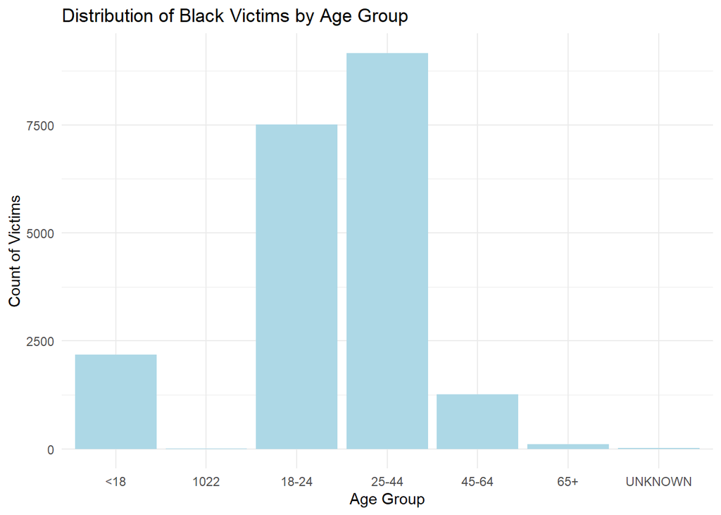

```r
ggplot(nyc_dataset[nyc_dataset$VIC_RACE == "BLACK", ], aes(x = VIC_AGE_GROUP)) +
  geom_bar(fill = "lightblue") +
  labs(title = "Distribution of Black Victims by Age Group",
       x = "Age Group",
       y = "Count of Victims") +
  theme_minimal()
```

# Question 1: Victim Proportion Estimate of Victims of Race Black

```r
prop.table(table(nyc_dataset$AGE_GROUP[nyc_dataset$VIC_RACE == "BLACK"]))
```

```
## numeric(0)
```

```r
total_victims <- nrow(nyc_dataset)


black_victims <- sum(nyc_dataset$VIC_RACE == "BLACK", na.rm = TRUE)


obs_proportion <- black_victims / total_victims
print(obs_proportion)
```

```
## [1] 0.7084588
```

```r
set.seed(123)


bootstrap_proportion_srs <- function(data, indices) {
  sampled_data <- data[sample(nrow(data), 5000 , replace = TRUE), ]
  mean(sampled_data$VIC_RACE == "BLACK", na.rm = TRUE)
}

boot_results_srs_black_victim <- boot(data = nyc_dataset_cleaned, statistic = bootstrap_proportion_srs, R = 1000)

obs_proportion <- mean(nyc_dataset_cleaned$VIC_RACE == "BLACK", na.rm = TRUE)
cat("Observed Proportion of Black Victims:", obs_proportion, "\n")
```

```
## Observed Proportion of Black Victims: 0.7084588
```

```r
print(boot_results_srs_black_victim)
```

```
##
## ORDINARY NONPARAMETRIC BOOTSTRAP
##
##
## Call:
## boot(data = nyc_dataset_cleaned, statistic = bootstrap_proportion_srs,
##     R = 1000)
##
##
## Bootstrap Statistics :
##     original    bias    std. error
## t1*    0.708 0.0003198 0.006563448
```

```r
boot_ci_srs_black_victim <- boot.ci(boot_results_srs_black_victim, type = "perc")


print(boot_ci_srs_black_victim)
```

```
## BOOTSTRAP CONFIDENCE INTERVAL CALCULATIONS
## Based on 1000 bootstrap replicates
##
## CALL :
## boot.ci(boot.out = boot_results_srs_black_victim, type = "perc")
##
## Intervals :
## Level     Percentile
## 95%   ( 0.6956,  0.7214 )
## Calculations and Intervals on Original Scale
```

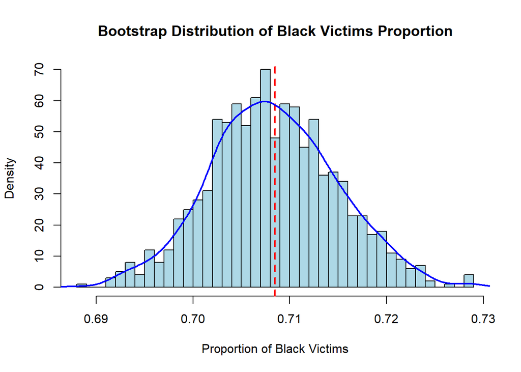

```r
hist(boot_results_srs_black_victim$t, main = "Bootstrap Distribution of Black Victims Proportion",
     xlab = "Proportion of Black Victims", col = "lightblue", border = "black",
     breaks = 30, probability = TRUE)


abline(v = obs_proportion, col = "red", lwd = 2, lty = 2)


lines(density(boot_results_srs_black_victim$t), col = "blue", lwd = 2)
```

The histogram shows that the proportion of Black victims in shootings consistently falls between ~69% and ~73% across bootstrap samples. This suggests that the high proportion of Black victims in NYC shootings is not due to random sampling variation but is a persistent trend in the data. The proportion is highly stable, implying that this finding is not sensitive to sampling fluctuations. The fact that the proportion of Black victims remains high across bootstrap samples raises important sociological, economic, and policing concerns. The observed proportion (~70.8%), indicated by the red dashed line, is near the peak of the distribution, confirming that it aligns with what we would expect based on repeated re sampling.

# Question 2: Proportions of Murders and The Difference In proportions between non-murder incidents and murder incidents

```r
set.seed(123)

nyc_dataset_cleaned$MURDER_FLAG <- ifelse(nyc_dataset$STATISTICAL_MURDER_FLAG == "true", 1, 0)

obs_proportion_murder <- mean(nyc_dataset_cleaned$MURDER_FLAG, na.rm = TRUE)
print(obs_proportion_murder)
```

```
## [1] 0.1934738
```

```r
bootstrap_proportion_murder <- function(data, indices) {
  sampled_data <- data[sample(nrow(data), 5000 , replace=TRUE), ]
  mean(sampled_data$MURDER_FLAG, na.rm = TRUE)
}


boot_results_murder <- boot(data = nyc_dataset_cleaned, statistic = bootstrap_proportion_murder, R = 1000)
```

```r
boot_ci_murder <- boot.ci(boot_results_murder, type = "perc")


print(boot_ci_murder)
```

```
## BOOTSTRAP CONFIDENCE INTERVAL CALCULATIONS
## Based on 1000 bootstrap replicates
##
## CALL :
## boot.ci(boot.out = boot_results_murder, type = "perc")
##
## Intervals :
## Level     Percentile
## 95%   ( 0.1826,  0.2042 )
## Calculations and Intervals on Original Scale
```

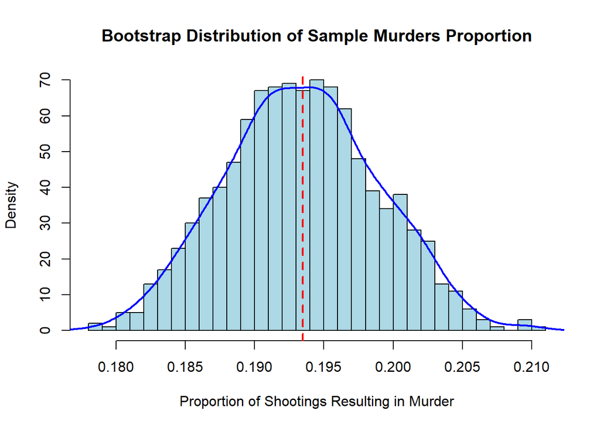

```r
hist(boot_results_murder$t, main = "Bootstrap Distribution of Sample Murders Proportion",
     xlab = "Proportion of Shootings Resulting in Murder",
     col = "lightblue", border = "black", breaks = 30, probability = TRUE)

abline(v = obs_proportion_murder, col = "red", lwd = 2, lty = 2)


lines(density(boot_results_murder$t), col = "blue", lwd = 2)
```

```r
set.seed(123)


nyc_dataset_cleaned$MURDER_FLAG <- ifelse(nyc_dataset_cleaned$STATISTICAL_MURDER_FLAG == "true", 1, 0)


total_shootings <- nrow(nyc_dataset_cleaned)


prop_murder <- mean(nyc_dataset_cleaned$MURDER_FLAG == 1, na.rm = TRUE)


prop_non_murder <- mean(nyc_dataset_cleaned$MURDER_FLAG == 0, na.rm = TRUE)


cat("Proportion of Shootings with Murder:", prop_murder, "\n")
```

```
## Proportion of Shootings with Murder: 0.1934738
```

```r
cat("Proportion of Shootings without Murder:", prop_non_murder, "\n")
```

```
## Proportion of Shootings without Murder: 0.8065262
```

```r
obs_diff <-  prop_non_murder - prop_murder
cat("Observed Difference in Proportions:", obs_diff, "\n")
```

```
## Observed Difference in Proportions: 0.6130523
```

```r
set.seed(123)


bootstrap_diff_murder <- function(data, indices) {
  sampled_data <- data[sample(nrow(data), 5000 , replace = TRUE), ]
  prop_murder_boot <- mean(sampled_data$MURDER_FLAG == 1, na.rm = TRUE)
  prop_non_murder_boot <- mean(sampled_data$MURDER_FLAG == 0, na.rm = TRUE)
  return(prop_non_murder_boot - prop_murder_boot)
}


boot_results_diff <- boot(data = nyc_dataset_cleaned, statistic = bootstrap_diff_murder, R = 1000)
```

```r
boot_ci_diff <- boot.ci(boot_results_diff, type = "perc")


print(boot_ci_diff)
```

```
## BOOTSTRAP CONFIDENCE INTERVAL CALCULATIONS
## Based on 1000 bootstrap replicates
##
## CALL :
## boot.ci(boot.out = boot_results_diff, type = "perc")
##
## Intervals :
## Level     Percentile
## 95%   ( 0.5916,  0.6348 )
## Calculations and Intervals on Original Scale
```

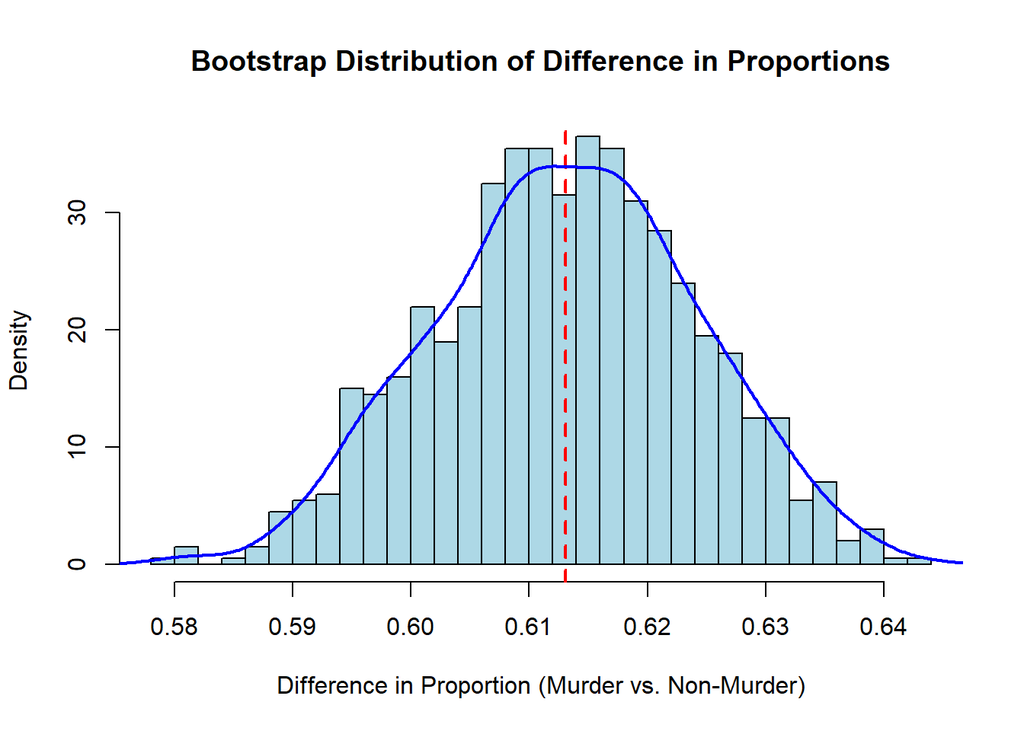

```r
hist(boot_results_diff$t, main = "Bootstrap Distribution of Difference in Proportions",
     xlab = "Difference in Proportion (Murder vs. Non-Murder)", col = "lightblue", border = "black",
     breaks = 30, probability = TRUE)


abline(v = obs_diff, col = "red", lwd = 2, lty = 2)


lines(density(boot_results_diff$t), col = "blue", lwd = 2)
```

The goal is to assess whether the proportion of one category (e.g., shootings resulting in murder) is significantly different from the other. The histogram and the blue density curve indicate that the distribution of the difference in proportions is bell-shaped and symmetric, suggesting that the sampling distribution of the proportion difference follows a normal-like shape.

This validates the assumption that the bootstrap sampling distribution can be used to construct confidence intervals.

The confidence interval also does not include 0, meaning that the proportion of murders among shootings is consistently different from the proportion of non-murders and statistically signficant. This suggests that certain factors may increase the likelihood of a shooting being fatal, such as:

- Firearm type used.
- Proximity of emergency medical services.
- Gang-related shootings vs. random acts of violence.